# TMDB Movies data set analysis

In this notebook i'll be going through Movies data set

# Step1: Gathering Data

downloaded the data `tmdb-movies.csv` from [Kaggle](https://d17h27t6h515a5.cloudfront.net/topher/2017/October/59dd1c4c_tmdb-movies/tmdb-movies.csv)

reading the data set into pandas data frame :

```python
import pandas as pd
import matplotlib.pyplot as plt
%matplotlib inline
df = pd.read_csv('tmdb-movies.csv')
df.head()
```

|  | id | imdb_id | popularity | budget | revenue | original_title | cast | homepage | director | tagline | ... | overview | runtime | genres | production_companies | release_date | vote_count | vote_average | release_year | budget_adj | revenue_adj |
| --- | --- | --- | --- | --- | --- | --- | --- | --- | --- | --- | --- | --- | --- | --- | --- | --- | --- | --- | --- | --- | --- |
| 0 | 135397 | tt0369610 | 32.985763 | 150000000 | 1513528810 | Jurassic World | Chris Pratt\|Bryce Dallas Howard\|Irrfan Khan\|Vi... | http://www.jurassicworld.com/ | Colin Trevorrow | The park is open. | ... | Twenty-two years after the events of Jurassic ... | 124 | Action\|Adventure\|Science Fiction\|Thriller | Universal Studios\|Amblin Entertainment\|Legenda... | 6/9/15 | 5562 | 6.5 | 2015 | 1.379999e+08 | 1.392446e+09 |
| 1 | 76341 | tt1392190 | 28.419936 | 150000000 | 378436354 | Mad Max: Fury Road | Tom Hardy\|Charlize Theron\|Hugh Keays-Byrne\|Nic... | http://www.madmaxmovie.com/ | George Miller | What a Lovely Day. | ... | An apocalyptic story set in the furthest reach... | 120 | Action\|Adventure\|Science Fiction\|Thriller | Village Roadshow Pictures\|Kennedy Miller Produ... | 5/13/15 | 6185 | 7.1 | 2015 | 1.379999e+08 | 3.481613e+08 |
| 2 | 262500 | tt2908446 | 13.112507 | 110000000 | 295238201 | Insurgent | Shailene Woodley\|Theo James\|Kate Winslet\|Ansel... | http://www.thedivergentseries.movie/#insurgent | Robert Schwentke | One Choice Can Destroy You | ... | Beatrice Prior must confront her inner demons ... | 119 | Adventure\|Science Fiction\|Thriller | Summit Entertainment\|Mandeville Films\|Red Wago... | 3/18/15 | 2480 | 6.3 | 2015 | 1.012000e+08 | 2.716190e+08 |
| 3 | 140607 | tt2488496 | 11.173104 | 200000000 | 2068178225 | Star Wars: The Force Awakens | Harrison Ford\|Mark Hamill\|Carrie Fisher\|Adam D... | http://www.starwars.com/films/star-wars-episod... | J.J. Abrams | Every generation has a story. | ... | Thirty years after defeating the Galactic Empi... | 136 | Action\|Adventure\|Science Fiction\|Fantasy | Lucasfilm\|Truenorth Productions\|Bad Robot | 12/15/15 | 5292 | 7.5 | 2015 | 1.839999e+08 | 1.902723e+09 |
| 4 | 168259 | tt2820852 | 9.335014 | 190000000 | 1506249360 | Furious 7 | Vin Diesel\|Paul Walker\|Jason Statham\|Michelle ... | http://www.furious7.com/ | James Wan | Vengeance Hits Home | ... | Deckard Shaw seeks revenge against Dominic Tor... | 137 | Action\|Crime\|Thriller | Universal Pictures\|Original Film\|Media Rights ... | 4/1/15 | 2947 | 7.3 | 2015 | 1.747999e+08 | 1.385749e+09 |

5 rows × 21 columns

# Step2: Asking questions

#### questions expected to be answered by the end of this analysis:

- What movie genre is associated with high average votes in the last couple years?
- What are the top 5 most popular movies in the last 5 years?
- Does high movie production budget results in high revenues?
- Average movie revenues in the last 2 years?
- How did movie production budget change from 1999 to 2015?
- What genre costs more in producation?

# Step3: Data Wrangling

## Assessing Data

- number of samples in the dataframe
- number of columns in the data frame
- columns with null values
- check for columns data types
- number of duplicated rows

```python
# number of samples and number of columns
len(df) , len(df.columns)
```

```
(10866, 21)
```

```python
# check for columns with null values
df.info()
```

```
<class 'pandas.core.frame.DataFrame'>
RangeIndex: 10866 entries, 0 to 10865
Data columns (total 21 columns):
 #   Column                Non-Null Count  Dtype
---  ------                --------------  -----
 0   id                    10866 non-null  int64
 1   imdb_id               10856 non-null  object
 2   popularity            10866 non-null  float64
 3   budget                10866 non-null  int64
 4   revenue               10866 non-null  int64
 5   original_title        10866 non-null  object
 6   cast                  10790 non-null  object
 7   homepage              2936 non-null   object
 8   director              10822 non-null  object
 9   tagline               8042 non-null   object
 10  keywords              9373 non-null   object
 11  overview              10862 non-null  object
 12  runtime               10866 non-null  int64
 13  genres                10843 non-null  object
 14  production_companies  9836 non-null   object
 15  release_date          10866 non-null  object
 16  vote_count            10866 non-null  int64
 17  vote_average          10866 non-null  float64
 18  release_year          10866 non-null  int64
 19  budget_adj            10866 non-null  float64
 20  revenue_adj           10866 non-null  float64
dtypes: float64(4), int64(6), object(11)
memory usage: 1.7+ MB
```

```python
# check for columns data types
df.dtypes
```

```
id                        int64
imdb_id                  object
popularity              float64
budget                    int64
revenue                   int64
original_title           object
cast                     object
homepage                 object
director                 object
tagline                  object
keywords                 object
overview                 object
runtime                   int64
genres                   object
production_companies     object
release_date             object
vote_count                int64
vote_average            float64
release_year              int64
budget_adj              float64
revenue_adj             float64
dtype: object
```

```python
# investigate release_date data type
type(df['release_date'][0])
```

```
str
```

```python
# checking for duplicates
df.duplicated().sum()
```

```
1
```

## Cleaning Data

```python
#drop columns not needed
df.drop(['homepage', 'overview', 'cast','tagline' ,'budget_adj' , 'revenue_adj'], axis=1, inplace=True)
```

```python
#drop duplicates
df = df.drop_duplicates()
#check if deleted
len(df) , df.duplicated().sum()
```

```
(10865, 0)
```

```python
#drop null valued rows
df.dropna();
```

```python
# convert release_date column from str to datetime type
df['release_date']=pd.to_datetime(df['release_date'])
```

```python
# handle 0 values in `budget` and `revenue` columns by filling it with the mean of the column values
df['budget'].replace(to_replace = 0, value = df['budget'].mean(), inplace=True)
df['revenue'].replace(to_replace = 0, value = df['revenue'].mean(), inplace=True)
```

```python
# check for changes
df.head()
```

|  | id | imdb_id | popularity | budget | revenue | original_title | director | keywords | runtime | genres | production_companies | release_date | vote_count | vote_average | release_year |
| --- | --- | --- | --- | --- | --- | --- | --- | --- | --- | --- | --- | --- | --- | --- | --- |
| 0 | 135397 | tt0369610 | 32.985763 | 150000000.0 | 1.513529e+09 | Jurassic World | Colin Trevorrow | monster\|dna\|tyrannosaurus rex\|velociraptor\|island | 124 | Action\|Adventure\|Science Fiction\|Thriller | Universal Studios\|Amblin Entertainment\|Legenda... | 2015-06-09 | 5562 | 6.5 | 2015 |
| 1 | 76341 | tt1392190 | 28.419936 | 150000000.0 | 3.784364e+08 | Mad Max: Fury Road | George Miller | future\|chase\|post-apocalyptic\|dystopia\|australia | 120 | Action\|Adventure\|Science Fiction\|Thriller | Village Roadshow Pictures\|Kennedy Miller Produ... | 2015-05-13 | 6185 | 7.1 | 2015 |
| 2 | 262500 | tt2908446 | 13.112507 | 110000000.0 | 2.952382e+08 | Insurgent | Robert Schwentke | based on novel\|revolution\|dystopia\|sequel\|dyst... | 119 | Adventure\|Science Fiction\|Thriller | Summit Entertainment\|Mandeville Films\|Red Wago... | 2015-03-18 | 2480 | 6.3 | 2015 |
| 3 | 140607 | tt2488496 | 11.173104 | 200000000.0 | 2.068178e+09 | Star Wars: The Force Awakens | J.J. Abrams | android\|spaceship\|jedi\|space opera\|3d | 136 | Action\|Adventure\|Science Fiction\|Fantasy | Lucasfilm\|Truenorth Productions\|Bad Robot | 2015-12-15 | 5292 | 7.5 | 2015 |
| 4 | 168259 | tt2820852 | 9.335014 | 190000000.0 | 1.506249e+09 | Furious 7 | James Wan | car race\|speed\|revenge\|suspense\|car | 137 | Action\|Crime\|Thriller | Universal Pictures\|Original Film\|Media Rights ... | 2015-04-01 | 2947 | 7.3 | 2015 |

# Step4: Exploring with visuals

- histograms of all features
- scatter plot shows the correlation between budget and revenue.
- scatter plot shows the relationship between release year and budget.

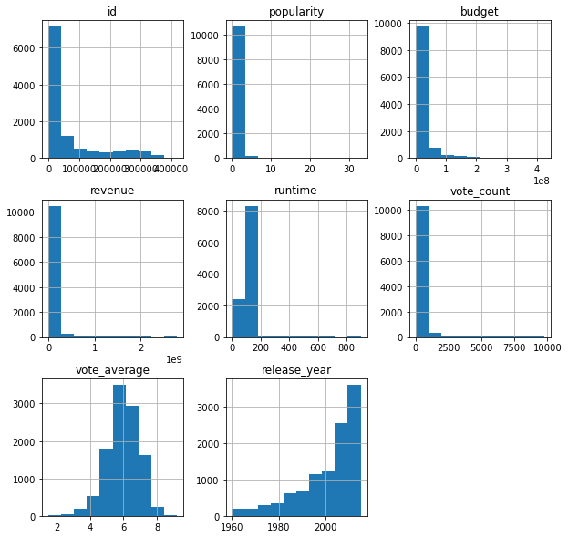

```python
df.hist(figsize=(10,10));
```

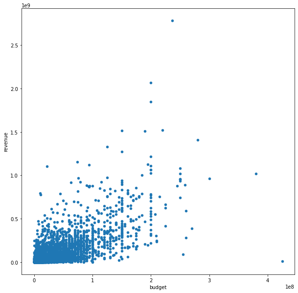

```python
df.plot(x='budget' , y='revenue',kind='scatter', figsize=(10,10));
```

the scatter plot shows a positive correlation between budget and revenue.

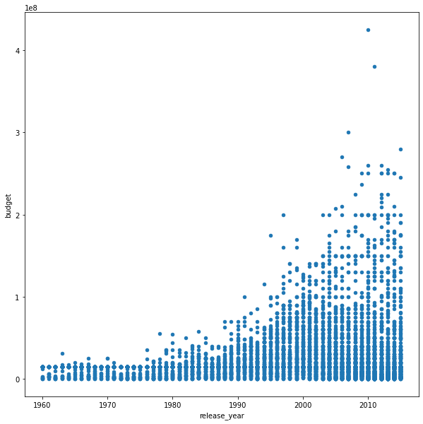

```python
df.plot(x='release_year' , y='budget' , kind='scatter' , figsize=(10,10));
```

and here its clear that movie production budget is increasing .

# Step5: Drawing Conclusions

### Q1:What movie genre is associated with high average votes in the last couple years?

```python
#select movies of last two years 2014&2015
df_last2years = df.query('release_year > 2013 ')
```

`genres` column has multiple values so first we need to make each values in a separate row

```python
# separate genres values into multiple rows
df_last2years["genres"] = df_last2years["genres"].str.split("|")
df_last2years = df_last2years.explode("genres")
df_last2years
```

|  | id | imdb_id | popularity | budget | revenue | original_title | director | keywords | runtime | genres | production_companies | release_date | vote_count | vote_average | release_year |
| --- | --- | --- | --- | --- | --- | --- | --- | --- | --- | --- | --- | --- | --- | --- | --- |
| 0 | 135397 | tt0369610 | 32.985763 | 1.500000e+08 | 1.513529e+09 | Jurassic World | Colin Trevorrow | monster\|dna\|tyrannosaurus rex\|velociraptor\|island | 124 | Action | Universal Studios\|Amblin Entertainment\|Legenda... | 2015-06-09 | 5562 | 6.5 | 2015 |
| 0 | 135397 | tt0369610 | 32.985763 | 1.500000e+08 | 1.513529e+09 | Jurassic World | Colin Trevorrow | monster\|dna\|tyrannosaurus rex\|velociraptor\|island | 124 | Adventure | Universal Studios\|Amblin Entertainment\|Legenda... | 2015-06-09 | 5562 | 6.5 | 2015 |
| 0 | 135397 | tt0369610 | 32.985763 | 1.500000e+08 | 1.513529e+09 | Jurassic World | Colin Trevorrow | monster\|dna\|tyrannosaurus rex\|velociraptor\|island | 124 | Science Fiction | Universal Studios\|Amblin Entertainment\|Legenda... | 2015-06-09 | 5562 | 6.5 | 2015 |
| 0 | 135397 | tt0369610 | 32.985763 | 1.500000e+08 | 1.513529e+09 | Jurassic World | Colin Trevorrow | monster\|dna\|tyrannosaurus rex\|velociraptor\|island | 124 | Thriller | Universal Studios\|Amblin Entertainment\|Legenda... | 2015-06-09 | 5562 | 6.5 | 2015 |
| 1 | 76341 | tt1392190 | 28.419936 | 1.500000e+08 | 3.784364e+08 | Mad Max: Fury Road | George Miller | future\|chase\|post-apocalyptic\|dystopia\|australia | 120 | Action | Village Roadshow Pictures\|Kennedy Miller Produ... | 2015-05-13 | 6185 | 7.1 | 2015 |
| ... | ... | ... | ... | ... | ... | ... | ... | ... | ... | ... | ... | ... | ... | ... | ... |
| 1325 | 286817 | tt3546114 | 0.032049 | 1.462429e+07 | 3.982690e+07 | Anatomy of a Love Seen | Marina Rice Bader | lesbian\|woman director | 86 | Romance | Soul Kiss Films | 2014-07-28 | 18 | 4.2 | 2014 |
| 1325 | 286817 | tt3546114 | 0.032049 | 1.462429e+07 | 3.982690e+07 | Anatomy of a Love Seen | Marina Rice Bader | lesbian\|woman director | 86 | Drama | Soul Kiss Films | 2014-07-28 | 18 | 4.2 | 2014 |
| 1326 | 250668 | tt2548738 | 0.023872 | 1.462429e+07 | 3.982690e+07 | Rich Hill | Tracy Droz Tragos\|Andrew Droz Palermo | woman director | 91 | Documentary | NaN | 2014-01-19 | 14 | 7.1 | 2014 |
| 1327 | 258614 | tt2966760 | 0.003504 | 1.462429e+07 | 3.982690e+07 | Pantani: The Accidental Death of a Cyclist | James Erskine | NaN | 90 | Documentary | NaN | 2014-02-17 | 11 | 6.5 | 2014 |
| 1328 | 288301 | tt3997238 | 0.002599 | 1.462429e+07 | 3.982690e+07 | Do I Sound Gay? | David Thorpe | homosexuality | 77 | Documentary | NaN | 2014-07-10 | 12 | 5.8 | 2014 |

2859 rows × 15 columns

```python
#check how many unique genres are there in the data frame
df_last2years['genres'].nunique()
```

```
19
```

apparentely there are 19 unique genres in this data set  
now lets see the average of each genre's vote_count?

```python
genres_vote_mean=df_last2years.groupby('genres').vote_count.mean()
genres_vote_mean
```

```
genres
Action             688.639831
Adventure          960.382353
Animation          380.346667
Comedy             294.221902
Crime              415.293103
Documentary         38.669231
Drama              271.095588
Family             376.850575
Fantasy            628.434783
History            368.100000
Horror             121.108696
Music              173.852459
Mystery            386.000000
Romance            246.666667
Science Fiction    775.864865
TV Movie            26.294118
Thriller           341.011429
War                598.312500
Western            702.916667
Name: vote_count, dtype: float64
```

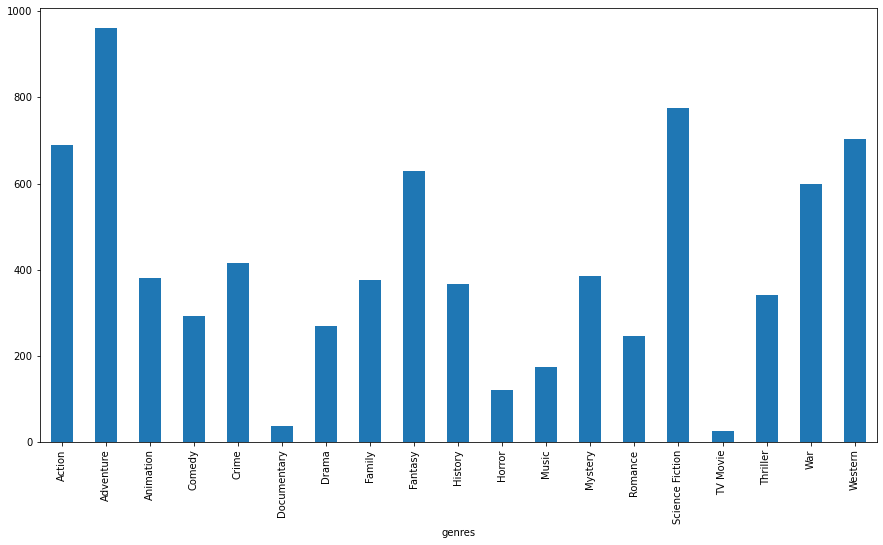

```python
genres_vote_mean.plot(x='genres' , y='vote_count' , kind='bar' , figsize=(15,8));
```

Apparentely, **adventure** movies are getting the highest average votes in the last couple years

### Q2:What are the top 5 most popular movies in the last 5 years?

```python
#select last 5 years movies
last_five_years = df.query('release_year > 2010')
```

sorting the samples by `popularity` in a descending order and viewing the top 5

```python
#top 5 popular movies in the last 5 years
last_five_years.sort_values(by=['popularity'] , ascending=False).head(5)
```

|  | id | imdb_id | popularity | budget | revenue | original_title | director | keywords | runtime | genres | production_companies | release_date | vote_count | vote_average | release_year |
| --- | --- | --- | --- | --- | --- | --- | --- | --- | --- | --- | --- | --- | --- | --- | --- |
| 0 | 135397 | tt0369610 | 32.985763 | 150000000.0 | 1.513529e+09 | Jurassic World | Colin Trevorrow | monster\|dna\|tyrannosaurus rex\|velociraptor\|island | 124 | Action\|Adventure\|Science Fiction\|Thriller | Universal Studios\|Amblin Entertainment\|Legenda... | 2015-06-09 | 5562 | 6.5 | 2015 |
| 1 | 76341 | tt1392190 | 28.419936 | 150000000.0 | 3.784364e+08 | Mad Max: Fury Road | George Miller | future\|chase\|post-apocalyptic\|dystopia\|australia | 120 | Action\|Adventure\|Science Fiction\|Thriller | Village Roadshow Pictures\|Kennedy Miller Produ... | 2015-05-13 | 6185 | 7.1 | 2015 |
| 629 | 157336 | tt0816692 | 24.949134 | 165000000.0 | 6.217525e+08 | Interstellar | Christopher Nolan | saving the world\|artificial intelligence\|fathe... | 169 | Adventure\|Drama\|Science Fiction | Paramount Pictures\|Legendary Pictures\|Warner B... | 2014-11-05 | 6498 | 8.0 | 2014 |
| 630 | 118340 | tt2015381 | 14.311205 | 170000000.0 | 7.733124e+08 | Guardians of the Galaxy | James Gunn | marvel comic\|spaceship\|space\|scene during end ... | 121 | Action\|Science Fiction\|Adventure | Marvel Studios\|Moving Picture Company (MPC)\|Bu... | 2014-07-30 | 5612 | 7.9 | 2014 |
| 2 | 262500 | tt2908446 | 13.112507 | 110000000.0 | 2.952382e+08 | Insurgent | Robert Schwentke | based on novel\|revolution\|dystopia\|sequel\|dyst... | 119 | Adventure\|Science Fiction\|Thriller | Summit Entertainment\|Mandeville Films\|Red Wago... | 2015-03-18 | 2480 | 6.3 | 2015 |

**Top 5 most popular movies in the last 5 years:**

1. Jurassic World
2. Mad Max: Fury Road
3. Interstellar
4. Guardians of the Galaxy
5. Insurgent

### Q3:Does high movie production budget results in high revenues?

```python
budget_mean = df['budget'].mean()
revenue_mean = df['revenue'].mean()
budget_mean ,  revenue_mean
```

```
(22291100.001054052, 61879229.88249824)
```

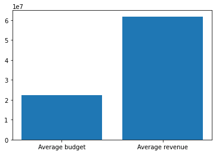

```python
plt.bar(['Average budget' , 'Average revenue'],[budget_mean ,  revenue_mean]);
```

Yes, the chart shows that high budget can result in even higher revenues

### Q4:Average movie revenues in the last 2 years?

```python
#select last 2 years movies
last_two_years = df.query('release_year > 2013')
```

```python
#calculate the mean revenue
last_two_years['revenue'].mean()
```

```
64966443.738912165
```

### Q5:How did movie production budget change from 1999 to 2015 ?

```python
#select 1999 movies
movies1999 = df.query('release_year == 1999')
#select 2015 movie
movies2015 = df.query('release_year == 2015')
```

```python
budgetMean1999 = movies1999['budget'].mean()
budgetMean2015 = movies2015['budget'].mean()
budgetMean1999 , budgetMean2015
```

```
(30634181.07511217, 21818956.149374202)
```

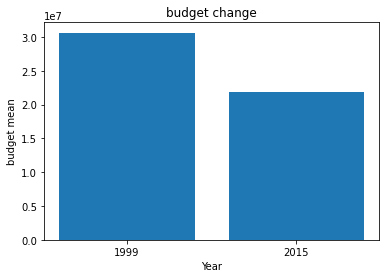

```python
#plot

plt.bar(['1999' , '2015'] , [budgetMean1999 ,budgetMean2015 ])
plt.title("budget change")
plt.xlabel("Year")
plt.ylabel("budget mean");
```

the bar chart shows that the average production budget has decreased from 1999 to 2015

### Q6:What genre costs more in producation?

```python
# separate genres values into multiple rows
split_genres = df[['genres', 'budget']].copy()
split_genres['genres'] = split_genres['genres'].str.split('|')
split_genres = split_genres.explode('genres')
```

```python
production_mean = split_genres.groupby('genres').budget.mean()
production_mean.sort_values(ascending=False).head(1)
```

```
genres
Adventure    4.316077e+07
Name: budget, dtype: float64
```

`Adventures` movies costs the most.

## Conclusions

### Result:

- Adveture movies has the highest votes in the last couple years and it is the genre that costs more in production
- High movie production budget can result in even higher revenues
- Movie revenues in the last couple years reached around `64,966443`
- Average movie production budget has declined from 1999 to 2015 with around `10,000000`
- Top 5 most popular movies in the last 5 years: Jurassic World , Mad Max:Fury Road , Interstellar , Guardians of the Galaxy , Insurgent

### Limitations:

- the numbers for budget and revenue columns lack accuracy and some are missing
- the data set contains multiple columns with multivalued columns which makes the analysis very limited.
- data set do not provide movie data after 2015
- there are a lot of NaN values.

**websites used for help with this analysis:**

- [Stack overflow](https://stackoverflow.com/questions/47462690/how-to-get-top-5-values-from-pandas-dataframe)
- [SparksBy examples](https://sparkbyexamples.com/pandas/pandas-create-new-dataframe-by-selecting-specific-columns/)
- [Pandas documentation](https://pandas.pydata.org/docs/reference/api/pandas.DataFrame.iloc.html)